# Intro to Jupyter Notebook.

Hello and Welcome to my blog. My ilttle notebook on how to do basic things on Python using your Jupyter notebook. Study the notes below to learn basic Python, GOOD LUCK!!!.

# Python can be used as a calculator

If you lost your calculator and you're using python, relax!!! you can use python as a calculator.

## Simple calculations:

- Phython can do simple calculations and follows the B.O.D.M.A.S rule.

```python
#Additions
A = 34 + 5

#Subtractions
B = 54 - 45

#Multiplications
M = 56 * 34

#Division
D = 56 / 5

#Expontial power
E = 5**6

#Modulas
R = 56%5

#show your answers
print(A)
print(B)
print(M)
print(D)
print(E)
print(R)
```

```
39
9
1904
11.2
15625
1
```

## Complex calculations:

For more complex calculations as means, standard deviations and so on you can use numpy which is a pre-installed package in our Jupyter notebook.

```python
import numpy as np
#make your array ready for numpy by inserting it inside a numpy.array() function
nums = np.array([45, 34, 66, 66, 54, 34, 454, 90, 54, 87, 98, 54, 8, 21, 3, 8, 9, 98, 56, 654, 956, 875, 54, 87, 1, 1])

#to calculate mean
print(np.mean(nums))

#Calculate standard deviation
print(np.std(nums))
```

```
152.57692307692307
261.5836640801743
```

## Printing Data on Python.

There are many ways to print data on many different languages. But to print data on Python we use the **Print()** function.

**Data** In Python can be both printed straight into the program using the **print()** function and straight into the **program cell**. Printing data trough the function is preferable.

### Printing strings on Python using Jupyter notebook.

To print strings(words) with the print function include quotation marks with your text, or simply write your string on the Jupyter notebook cells in qoutation marks. Notice the difference between using the function and printing straight to cell.

```python
#If you input: print(Hello World); the program will return an error(invalid syntax) and cause the program not to continue.
print("Hello world") #When writing a string always to make sure to include your quotation marks before your string.

#To display data you can always just input your string with your quotation marks.
'Hello world'
#Try the difference between print('hello python'), print(Hello python) & "Hello python", in the below cell.
```

```
Hello world
```

```
'Hello world'
```

```python
#Test your skills and the difference Here ;-)
```

### Printing Variables on Python using Jupyter notebook.

- *Variable*- is a quantity that may change within the context of a mathematical problem or experiment.

#### Set variable.

Before a variable can be printed by a Program it needs to be set so that the program can read it then show it. Usually *variables* are SET in the earlier stages of a program then are requested in the later stages of the program. Here are simple tutorials on how to set your *variables* in code.

```python
#first choose a variable name you'll remember. let's take VAR for our variable, then set it's value.
var = '95' #Just choose a name then equate it to the desired value.
print(var) #you can always call the var at a later stage by it's var name.

strings_too = 'You can store strings as variables too' #strings can be stored too.
print(strings_too)
```

```
95
You can store strings as variables too
```

##### Rules of setting variable names

**Ofcause even setting variable names has rules.**

- **Variable names dont start with numerical values.**
- **Variable names are CasE SENsEtiVe.**
- **Variable names can start with an *underscore*( _ ).**
- **Variable names cant contain special characters other than the ( _ ).**

## *Arrays (list)*

- Python can also store data or information in a form of a list called **Arrays**, for convenience. instead of creating many variable you can create a single variable containing all the appropriate data. lets study arrays.

```python
#Create your variable name. in this case it's Groceries.\

groceries = ['Orange ' * 2, 'Nartjie ' * 5, 'Pizza spice', 'Food', 'Milk ' * 2]

print(groceries)
```

[output not shown]

**As in the example above, to create an array create the var name equate it to your list** **To create a list in clude all your components/ elements inside square brackets and separate them by commas then, voila! you've got a list.** **For more assurity see above list.**

## Adding arrays

- To add two or more arrays together simply call the desired arrays then add them by the + operative to produce a new array.

```python
#Jus add them using the + operator.
random_numbers = [3, 3 ,5 , 77, 67]
twos_fours = [2, 4, 2, 2, 4 ]
adding = random_numbers + twos_fours
print(adding)
#Add arrays to create a new but longer singular array.
```

```
[3, 3, 5, 77, 67, 2, 4, 2, 2, 4]
```

## Indexing

- Let's say you want a specific fruit in your array this is were indexing comes into play. we use indexing to pick out a specific element or component.
- In the list below we want the fourth fruit let's use indexing to pick our fruit.
- To index just call the name of your list then square brackets, inside input the position of your desired coponent in this case fruit.

```python
my_fruits = ['Apple', 'Pineapple', 'fruits', 'other fruit', 'Orange', 'Nartjie']
#Phyton uses Zero-based indexing meaning it starts counting from zero, so the position of your first fruit is zero and so on

my_fruits[3] #to print the 4th fruit use 3 as your position.
```

```
'other fruit'
```

## Phython slicing on Jupyter notebook

- If you want to a certain potion of your list, it's totally inconvinient to index each and every component, this is were slicing comes in.
- Python developed a way to cut a chunk of an array called **Slicing**

```python
#To slice everything in the list just input the colon in the indexing square brackets.
#Slicing everything is mostly used to creat a list as same asthe previous list.


new = my_fruits[:]   #The colon inside the bracket selects everything from the list my_fruit.
print(new)           #Now the list new has everything my_fruits has. they are now identcal
```

```
['Apple', 'Pineapple', 'fruits', 'other fruit', 'Orange', 'Nartjie']
```

```python
#To slice certain parts of a list in clude positions of the first component before the colon then the last position
my_fruits = ['Apple', 'Pineapple', 'fruits', 'other fruit', 'Orange', 'Nartjie']
my_fruits[:3]
```

```
['Apple', 'Pineapple', 'fruits']
```

## Importing packages.

Something are impossible/too hard to execute manually such as plotting graphs in python for things we use packages.

```python
#To import packages we add i mport line inside our python code.
#Jupyter already has pre-installed packages you just need to import them.
import numpy
#Set package name you'll remember with the "as" line
import numpy as my_num
#I chose my_num cause i'll remember it.
```

# dictionaries

**A Python dictionary is a mapping of unique keys to values**. Dictionaries are mutable, which means they can be changed. To create a dictionary add your content in curled brackets( {} ) then separate your variable from it's value with a colon (:).

```python
my_dictionary = {
    "first":"first value",
    "second":"second value",
    "third":"third value",
    "fourth":"fourth value",
    "fifth":"fifth value"
}
#To call value of your dictionary variable just index your variable.
my_dictionary["first"]
```

```
'first value'
```

# Plotting Graphs

To plot graphs you need the matplotlib package. To plot different graphs you can use different syntexes:

## Bar graphs:

To plot bar graphs use the bargraph syntex : matplolib.bar( arrayA, arrayB)

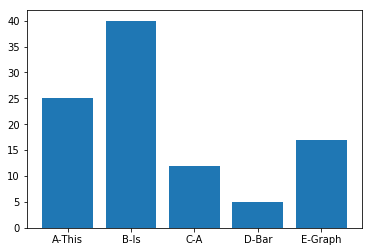

```python
arrayA = ["A-This", "B-Is", "C-A", "D-Bar", "E-Graph"]
arrayB = [25, 40, 12, 5, 17]

import numpy as np
import matplotlib.pyplot as plt

plt.bar(arrayA, arrayB)
plt.show() #Always use the show() function to see your graph.
```

## Histograms

use the histogram if you have a continuous data for the x-axes eg. Time, Age and weight.

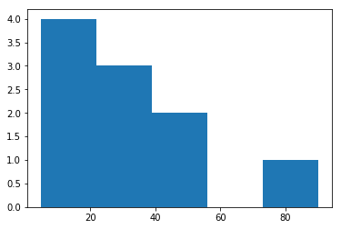

```python
import numpy as np
import matplotlib.pyplot as plt

x_array = [5, 10, 15, 20, 25,30, 23, 45, 52, 90]

plt.hist(x_array,bins=5) #You can also set the number of bins.
plt.show()
```

## Line graph:

- line graphs are great for observing growth.

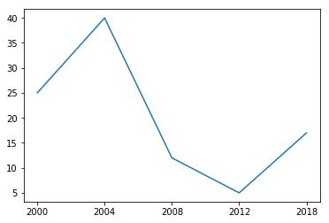

```python
arrayA = ["2000", "2004", "2008", "2012", "2018"]
arrayB = [25, 40, 12, 5, 17]

plt.plot(arrayA, arrayB)
plt.show()
```

## *Scatter plot*

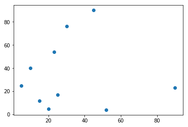

```python
import numpy as np
import matplotlib.pyplot as plt
x_array = [5, 10, 15, 20, 25,30, 23, 45, 52, 90]
arrayB = [25, 40, 12, 5, 17, 76, 54, 90, 4, 23]

plt.scatter(x_array, arrayB)
plt.show()
```

# Labeling graphs:

Let's give our graphs labels from **Title** to the **x-axis label**.

```
Text(0.5,0,'This is my xlabel')
```

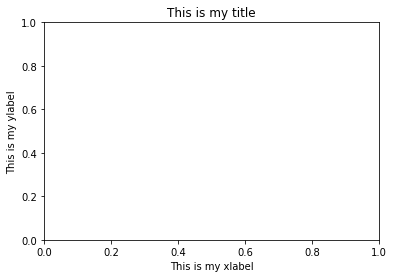

```python
#For the title use the title() function
plt.title("This is my title")
#For the y-label use the ylabel() function:
plt.ylabel("This is my ylabel")
#For the x-label use the ylabel() function:
plt.xlabel("This is my xlabel")
```

# Plot full graph.

**Its time to plot your full graph!.**

```python
import numpy as np #Remember to import your packages.
import matplotlib.pyplot as plt

arrayA = [5, 10, 15, 20, 25,30, 23, 45, 52, 90] #have your x-values set.
arrayB = [25, 40, 12, 5, 17, 76, 54, 90, 4, 23] #have y-values set.

plt.scatter(arrayA, arrayB)
plt.title("Title of my graph.") # write the title of your graph
plt.xlabel("my x values") # write your x label
plt.ylabel("my y values") #write your y label
plt.show() #Remember to show your scatter plot
```

[output not shown]

# Dataframes

- If you have to much data and you want display that data in an organised way you can use **dataframes**.
- In the example we will use towed cars in the past 30 days.
- This is obviously too much info.

```python
url = 'https://data.hartford.gov/api/views/hefc-wgp8/rows.csv?accessType=DOWNLOAD'
import pandas as pd
cohorts = pd.read_csv(url)
cohorts
```

|  | TowNum | Tow_Firm | Tow_Firm_Address | Tow_Firm_Phone | Vehicle_State | Vehicle_Plate | Vehicle_Year | Make | Model | Color | Tow_From_Address | Date | Time | geom |
| --- | --- | --- | --- | --- | --- | --- | --- | --- | --- | --- | --- | --- | --- | --- |
| 0 | 348629 | A & N AUTO | 1516,PARK ST,HARTFORD,CT,06106 | 860-233-7079 | CT | 725WYU | 2006 | TOYT | PRIUS | SILV | NaN | 4202018 | 1910 | (41.7447179073531, -72.683290606054) |
| 1 | 348401 | CENTRAL AUTO & TRANSPORT, LLC | 195 MAXIM RD. HARTFORD, CT 06114 | 860-246-7616 | MA | BOBAH | 2012 | BMW | X6 | BLUE | NaN | 4152018 | 109 | (41.785038296753, -72.6610057252867) |
| 2 | 348399 | CAPITOL AUTOMOTIVE LLC | 971 CAPITOL AV. HARTFORD,CT 06106 | 860-236-2602 | TX | 318152F | 2004 | NISSAN | MAXIMA | BROWN | NaN | 4152018 | 37 | (41.7327450021826, -72.7095924470287) |
| 3 | 348398 | CROSS COUNTRY AUTO | 585 WINDOSR ST. HARTFORD, CT 06120 | 860-296-2826 | CT | AJ92888 | 2005 | NISSAN | ALTIMA | BLACK | NaN | 4152018 | 31 | (41.7702080582161, -72.7002667376841) |
| 4 | 348400 | CROSS COUNTRY AUTO | 585 WINDOSR ST. HARTFORD, CT 06120 | 860-296-2826 | CT | 5AKEA2 | 2002 | JEEP | LIBERTY | TAN | NaN | 4152018 | 108 | (41.771584686662, -72.6935243427996) |
| 5 | 348403 | NaN | NaN | 860-246-7616 | CT | 7AMLL4 | 2012 | HONDA | ACCORD | SILVER | NaN | 4152018 | 149 | (41.7937707552857, -72.6642990929705) |
| 6 | 348404 | CENTRAL GARAGE | 36 BOND ST. HARTFORD,CT 06114 | 860-296-1426 | CT | AA06968 | 2014 | FORD | FOCUS | GRAY | NaN | 4152018 | 155 | (41.737310451092, -72.6926304348045) |
| 7 | 348405 | NaN | NaN | 860-296-1426 | CT | AL10327 | 2007 | HONDA | ACCORD | RED | NaN | 4152018 | 156 | (41.7937707552857, -72.6642990929705) |
| 8 | 348402 | NaN | NaN | 860-246-7616 | CT | AB62760 | 2005 | HONDA | ACCORD | BLACK | NaN | 4152018 | 146 | (41.7937707552857, -72.6642990929705) |
| 9 | 348406 | NaN | NaN | 860-296-1426 | CT | AG68380 | 2008 | NISSAN | ALTIMA | BLUE | NaN | 4152018 | 200 | (41.7937707552857, -72.6642990929705) |
| 10 | 348407 | CROSS COUNTRY AUTO | 585 WINDOSR ST. HARTFORD, CT 06120 | 860-296-2826 | TX | 298411F | 2006 | TOYOTA | AVALON | BLUE | NaN | 4152018 | 225 | (41.7559809822894, -72.6937648336205) |
| 11 | 348408 | CROSS COUNTRY AUTO | 585 WINDOSR ST. HARTFORD, CT 06120 | 860-296-2826 | CT | AM44166 | 2018 | FORD | ESCAPE | GRAY | NaN | 4152018 | 230 | (41.7815669369853, -72.6883941871754) |
| 12 | 348409 | CORONA'S AUTO PARTS,INC. | 608 WETHERSFIELD AV. HARTFORD CT. 06114 | 860-296-5382 | CT | AG89942 | 2004 | ACURA | TSX | WHITE | NaN | 4152018 | 234 | (41.7602296714444, -72.6890684881454) |
| 13 | 348410 | NaN | NaN | 860-296-5382 | FL | 661JBI | 2015 | HYUNDAI | SONATA | SILVER | NaN | 4152018 | 241 | (41.7931171474424, -72.6657062559219) |
| 14 | 348411 | CROSS COUNTRY AUTO | 585 WINDOSR ST. HARTFORD, CT 06120 | 860-296-2826 | CT | AH50777 | 2010 | ACURA | TL | GRAY | NaN | 4152018 | 249 | (41.7600724166921, -72.6894338652256) |
| 15 | 348412 | CROSS COUNTRY AUTO | 585 WINDOSR ST. HARTFORD, CT 06120 | 860-296-2826 | CT | AF96889 | 2002 | VOLKSWAGON | JETTA | GRAY | NaN | 4152018 | 315 | (41.7815669369853, -72.6883941871754) |
| 16 | 348414 | MODERN GARAGE | 100A,AIRPORT RD,HARTFORD,CT,06114 | 860-296-9663 | CT | 00FFYW | 1991 | HONDA | CIVIC | RED | NaN | 4152018 | 550 | (41.7575425221239, -72.6849263840346) |
| 17 | 348415 | CROSS COUNTRY AUTO | 585 WINDOSR ST. HARTFORD, CT 06120 | 860-296-2826 | CT | AJ04179 | 2014 | NISSAN | MAXIMA | GRAY | NaN | 4152018 | 553 | (41.7815669369853, -72.6883941871754) |
| 18 | 348416 | RENO'S AUTO BODY | 525 FRANKLIN AV. HARTFORD, CT 06114 | 860-296-1518 | CT | 4ANMM0 | 2015 | NISSAN | VERSA | BLUE | NaN | 4152018 | 628 | (41.7842967573932, -72.6942329030532) |
| 19 | 348417 | WHITEY'S FRAME SHOP | 305 WEST SERVICE RD. HARTFORD, CT 06120 | 860-246-6871 | NaN | NaN | 2002 | CHEVROLET | TRAILBLAZE | BLUE | NaN | 4152018 | 628 | (41.7842967573932, -72.6942329030532) |
| 20 | 348418 | A & N AUTO | 1516,PARK ST,HARTFORD,CT,06106 | 860-233-7079 | CT | AN29556 | 2005 | TOYOTA | COROLLA | WHI | NaN | 4152018 | 809 | (41.7579337717286, -72.6823593632626) |
| 21 | 348420 | CAPITOL TOWING | 181-211 WALNUT ST. HARTFORD, CT. 06120 | 860-293-2442 | CT | AN56571 | 2012 | HYUNDAI | SANTE | GRY | NaN | 4152018 | 1410 | (41.7479637170177, -72.7033323722109) |
| 22 | 348419 | BENTON AUTO BODY | 155 FRANKLIN AV. HARTFORD, CT 06114 | 860-246-7771 | NaN | NaN | 2005 | NISSAN | ALTIMA | TAN | NaN | 4152018 | 1325 | (41.7409446576117, -72.6856733150446) |
| 23 | 348423 | NaN | NaN | 860-236-2602 | CT | 883ZDA | 2007 | HYUNDAI | SONATA | SILVER | NaN | 4152018 | 1618 | (41.7728834468306, -72.6891063832292) |
| 24 | 348422 | NaN | NaN | 860-236-2602 | CT | AJ86798 | 2004 | TOYOTA | COROLLA | BLUE | NaN | 4152018 | 1611 | (41.7458487936474, -72.682857900576) |
| 25 | 348421 | CAPITOL AUTOMOTIVE LLC | 971 CAPITOL AV. HARTFORD,CT 06106 | 860-236-2602 | CT | 335DSM | 1998 | TOYOTA | COROLLA | BLU | NaN | 4152018 | 1548 | (41.7269855104057, -72.6911291585753) |
| 26 | 348424 | CROSS COUNTRY AUTO | 585 WINDOSR ST. HARTFORD, CT 06120 | 860-296-2826 | MA | 372KH9 | 2005 | LEXUS | RX330 | BLACK | NaN | 4152018 | 1805 | (41.8006137013404, -72.7174254161015) |
| 27 | 348426 | CENTRAL GARAGE | 36 BOND ST. HARTFORD,CT 06114 | 860-296-1426 | OR | CA92666 | 1996 | TOYOTA | CAMRY | GRN | NaN | 4152018 | 1856 | (41.7659188305163, -72.7135585849239) |
| 28 | 348425 | CENTRAL AUTO & TRANSPORT, LLC | 195 MAXIM RD. HARTFORD, CT 06114 | 860-246-7616 | CT | DD2790 | 0 | MERZ | SL500 | BLU | NaN | 4152018 | 1854 | (41.7659188305163, -72.7135585849239) |
| 29 | 348428 | CROSS COUNTRY AUTO | 585 WINDOSR ST. HARTFORD, CT 06120 | 860-296-2826 | CT | AL65974 | 2004 | DODGE | STRATUS | PUR | NaN | 4152018 | 2011 | (41.7714369406819, -72.6742856919419) |
| ... | ... | ... | ... | ... | ... | ... | ... | ... | ... | ... | ... | ... | ... | ... |
| 951 | 349469 | NaN | NaN | 860-296-2826 | CT | AD11919 | 2002 | ACURA | TL | SILVER | NaN | 5132018 | 1426 | (41.7402263859838, -72.6993548558059) |
| 952 | 349470 | CAPITOL AUTOMOTIVE LLC | 971 CAPITOL AV. HARTFORD,CT 06106 | 860-236-2602 | CT | AF02515 | 2013 | HUYUNDI | ELANTRA | WHITE | NaN | 5132018 | 1521 | (41.743830669956, -72.7021419931589) |
| 953 | 349472 | CENTRAL AUTO & TRANSPORT, LLC | 195 MAXIM RD. HARTFORD, CT 06114 | 860-246-7616 | CT | AK23300 | 2015 | NISS | ALTIMA | BLK | NaN | 5132018 | 1830 | (41.7611805209974, -72.7154534526861) |
| 954 | 349474 | CROSS COUNTRY AUTO | 585 WINDOSR ST. HARTFORD, CT 06120 | 860-296-2826 | CT | AM72409 | 2001 | HONDA | CIVIC | GRY | NaN | 5132018 | 1911 | (41.7589998117031, -72.6990911447539) |
| 955 | 349476 | NaN | NaN | 860-296-2826 | NaN | NaN | 2004 | JEEP | CHEROKEE | BLACK | NaN | 5142018 | 156 | (41.742195462416, -72.6714929244279) |
| 956 | 349475 | NaN | NaN | 860-296-2826 | NaN | NaN | 2000 | CHEVROLET | EXPRESS VA | BLUE | NaN | 5142018 | 153 | (41.742195462416, -72.6714929244279) |
| 957 | 349477 | NaN | NaN | 860-296-2826 | CT | AD12215 | 2001 | FORD | ESCAPE | TAN | NaN | 5142018 | 158 | (41.742195462416, -72.6714929244279) |
| 958 | 349480 | CROSS COUNTRY AUTO | 585 WINDOSR ST. HARTFORD, CT 06120 | 860-296-2826 | CT | 8ASHN9 | 2007 | TOYOTA | CAMRY | RED | NaN | 5142018 | 328 | (41.7724793087826, -72.6928372421875) |
| 959 | 349479 | CROSS COUNTRY AUTO | 585 WINDOSR ST. HARTFORD, CT 06120 | 860-296-2826 | CT | 5AHVD1 | 2013 | NISSAN | ROGUE | RED | NaN | 5142018 | 325 | (41.7700025470151, -72.6947931533328) |
| 960 | 349483 | METRO AUTOBODY & TOWING INC | 722 WETHERSFIELD AV HARTFORD CT 06114 | 860-947-3062 | CT | AH11998 | 2014 | NISSAN | MAXIMA | GRAY | NaN | 5142018 | 644 | (41.7467268555749, -72.6822926613406) |
| 961 | 349482 | FRIENDLY AUTO BODY & TOWING | 99 MEADOW ST. HARTFORD, CT. 06114 | 860-296-8588 | CT | AL11093 | 1997 | NISSAN | ALTIMA | RED | NaN | 5142018 | 617 | (41.7560754967422, -72.7121800125386) |
| 962 | 349484 | MODERN GARAGE | 100A,AIRPORT RD,HARTFORD,CT,06114 | 860-296-9663 | CT | C058414 | 2003 | TOYOTA | RAV4 | SILVER | NaN | 5142018 | 651 | (41.7560754967422, -72.7121800125386) |
| 963 | 349487 | NaN | NaN | 860-296-1518 | VA | VXL7828 | 2017 | NISS | SENA | BLUE | NaN | 5142018 | 836 | (41.7886477966288, -72.6800342842375) |
| 964 | 349486 | RENO'S AUTO BODY | 525 FRANKLIN AV. HARTFORD, CT 06114 | 860-296-1518 | CT | AA23045 | 2003 | CHEVY | TRAILBLAZE | TAN | NaN | 5142018 | 828 | (41.7584565389942, -72.6894851810671) |
| 965 | 349490 | BENTON AUTO BODY | 155 FRANKLIN AV. HARTFORD, CT 06114 | 860-246-7771 | CT | AP05306 | 2001 | MAZDA | 626 | GREEN | NaN | 5142018 | 1003 | (41.7757602918058, -72.6771699630357) |
| 966 | 349489 | A & N AUTO | 1516,PARK ST,HARTFORD,CT,06106 | 860-233-7079 | NaN | NaN | 2003 | HONDA | ACCORD | GRAY | NaN | 5142018 | 958 | (41.7533287099512, -72.6848808224938) |
| 967 | 349488 | WHITEY'S FRAME SHOP | 305 WEST SERVICE RD. HARTFORD, CT 06120 | 860-246-6871 | CT | 3AKJD2 | 2005 | FORD | EXPLORER | GRAY | NaN | 5142018 | 941 | (41.7800985398283, -72.6843888898329) |
| 968 | 349491 | CAPITOL TOWING | 181-211 WALNUT ST. HARTFORD, CT. 06120 | 860-293-2442 | CT | 1AAFH1 | 2005 | VOLKSWAGON | JETTA | BLUE | NaN | 5142018 | 1006 | (41.7566086780686, -72.7083726686625) |
| 969 | 349492 | FRIENDLY AUTO BODY & TOWING | 99 MEADOW ST. HARTFORD, CT. 06114 | 860-296-8588 | NaN | NaN | 2001 | NISSAN | MAXIMA | GRAY | NaN | 5142018 | 1136 | (41.7819961539224, -72.6793160824971) |
| 970 | 349493 | NaN | NaN | 860-296-8588 | CT | 1848CX | 2003 | FORD | F150 | RED | NaN | 5142018 | 1245 | (41.7607544038799, -72.6869818628777) |
| 971 | 349495 | NaN | NaN | 860-296-8588 | CT | 3AGXH6 | 2009 | FORD | TAURUS | BLUE | NaN | 5142018 | 1319 | (41.7552960988563, -72.6705308241588) |
| 972 | 349494 | NaN | NaN | 860-296-8588 | CT | 619ZPB | 2015 | CHEVROLET | EQUINOX | BLACK | NaN | 5142018 | 1308 | (41.7712763963602, -72.6901816333271) |
| 973 | 349496 | NaN | NaN | 860-296-8588 | CT | 3AXFB7 | 2005 | HONDA | ACCORD | BLUE | NaN | 5142018 | 1409 | (41.7773596489169, -72.7007372706161) |
| 974 | 349497 | NaN | NaN | 860-296-8588 | CT | AD44473 | 2001 | ACRUA | CL | TAN | NaN | 5142018 | 1511 | (41.7620117599088, -72.7088174412855) |
| 975 | 349499 | NaN | NaN | 860-296-8588 | CT | AC25653 | 2013 | HONDA | ACCORD | GRAY | NaN | 5142018 | 1536 | (41.7700025470151, -72.6947931533328) |
| 976 | 349500 | NaN | NaN | 860-296-8588 | PA | GWA9936 | 1999 | BMW | 323I | GREEN | NaN | 5142018 | 1546 | (41.7307541070946, -72.669299825846) |
| 977 | 349501 | NaN | NaN | 860-296-8588 | CT | AH20094 | 2007 | TOYOTA | YARIS | RED | NaN | 5142018 | 1902 | (41.7682137200841, -72.6971302265247) |
| 978 | 349502 | NaN | NaN | 860-296-8588 | CT | 3AJDH4 | 2007 | JEEP | WRANGLER | SILVER | NaN | 5142018 | 2221 | (41.77159955912, -72.6901481263552) |
| 979 | 349504 | CENTRAL AUTO & TRANSPORT, LLC | 195 MAXIM RD. HARTFORD, CT 06114 | 860-246-7616 | CT | 6AFDW4 | 2008 | LEXUS | ES350 | GRAY | NaN | 5152018 | 126 | (41.7911862753024, -72.6865699575155) |
| 980 | 349503 | CAPITOL AUTOMOTIVE LLC | 971 CAPITOL AV. HARTFORD,CT 06106 | 860-236-2602 | CT | 152RKU | 1992 | HONDA | ACCORD | GREEN | NaN | 5152018 | 120 | (41.7423402157749, -72.6774177984678) |

981 rows × 14 columns

## HTML content in python using Jupyter.

To add some Html Elements such as videos and Audio, Using python use ipython multiline cell alias. Before adding your html content just add The alias in a new line **%%HTML**, then add your HTML code below your *%%hmtl alias*.

```python
%%HTML
<iframe width="100%" height="500"
src="https://www.youtube.com/embed/tgbNymZ7vqY">
</iframe>
```

[video not shown]